- Authors: Andrea Jiménez Zuñiga e Isabel Afán de Ribera
- Date: 04/12/2020
- Institution: CUNEF

# 01. EDA Lending Club

## Introduction

LendingClub was an American peer-to-peer lending company, headquartered in San Francisco, California. It was the first peer-to-peer lender to register its offerings as securities with the Securities and Exchange Commission (SEC), and to offer loan trading on a secondary market.

The aim of this project is to analyse, as employees of the Lending Club, whether the customers who apply for loans from us meet the necessary requirements to receive our approval or not. To do so, we will carry out an exploration of the dataset, analyse the data and predict our decision through different predictive models. Subsequently, we will evaluate which model is more appropriate for our decision making.

## Import Libraries

```python
import pandas as pd
import numpy as np
import matplotlib.pyplot as plt
%matplotlib inline
import seaborn as sns
```

## Import Data

```python
datos1 = pd.read_csv('/Users/Andy/Desktop/CUNEF/MACHINE LEARNIG/Prestamos/data/Loan_training_set_1_4.csv', header=1, skipfooter=2)

datos2 = pd.read_csv('/Users/Andy/Desktop/CUNEF/MACHINE LEARNIG/Prestamos/data/Loan_training_set_2_4.csv', header = 1, skipfooter=2)
datos3 = pd.read_csv('/Users/Andy/Desktop/CUNEF/MACHINE LEARNIG/Prestamos/data/Loan_training_set_3_4.csv', header = 1, skipfooter=2)

datos4 = pd.read_csv('/Users/Andy/Desktop/CUNEF/MACHINE LEARNIG/Prestamos/data/Loan_training_set_4_4.csv', header = 1, skipfooter=2)
```

```python
datos1.tail()
```

|  | id | member_id | loan_amnt | funded_amnt | funded_amnt_inv | term | int_rate | installment | grade | sub_grade | ... | hardship_payoff_balance_amount | hardship_last_payment_amount | disbursement_method | debt_settlement_flag | debt_settlement_flag_date | settlement_status | settlement_date | settlement_amount | settlement_percentage | settlement_term |
| --- | --- | --- | --- | --- | --- | --- | --- | --- | --- | --- | --- | --- | --- | --- | --- | --- | --- | --- | --- | --- | --- |
| 105446 | 102556443 | NaN | 24000 | 24000 | 24000 | 60 months | 23.99% | 690.30 | E | E2 | ... | NaN | NaN | Cash | N | NaN | NaN | NaN | NaN | NaN | NaN |
| 105447 | 102653304 | NaN | 10000 | 10000 | 10000 | 36 months | 7.99% | 313.32 | A | A5 | ... | NaN | NaN | Cash | N | NaN | NaN | NaN | NaN | NaN | NaN |
| 105448 | 102628603 | NaN | 10050 | 10050 | 10050 | 36 months | 16.99% | 358.26 | D | D1 | ... | NaN | NaN | Cash | N | NaN | NaN | NaN | NaN | NaN | NaN |
| 105449 | 102196576 | NaN | 6000 | 6000 | 6000 | 36 months | 11.44% | 197.69 | B | B4 | ... | NaN | NaN | Cash | N | NaN | NaN | NaN | NaN | NaN | NaN |
| 105450 | 99799684 | NaN | 30000 | 30000 | 30000 | 60 months | 25.49% | 889.18 | E | E4 | ... | NaN | NaN | Cash | N | NaN | NaN | NaN | NaN | NaN | NaN |

5 rows × 151 columns

```python
datos2.tail()
```

|  | id | member_id | loan_amnt | funded_amnt | funded_amnt_inv | term | int_rate | installment | grade | sub_grade | ... | hardship_payoff_balance_amount | hardship_last_payment_amount | disbursement_method | debt_settlement_flag | debt_settlement_flag_date | settlement_status | settlement_date | settlement_amount | settlement_percentage | settlement_term |
| --- | --- | --- | --- | --- | --- | --- | --- | --- | --- | --- | --- | --- | --- | --- | --- | --- | --- | --- | --- | --- | --- |
| 122696 | 110380307 | NaN | 6000 | 6000 | 6000 | 36 months | 23.88% | 235.02 | E | E2 | ... | NaN | NaN | Cash | N | NaN | NaN | NaN | NaN | NaN | NaN |
| 122697 | 110479222 | NaN | 20000 | 20000 | 20000 | 60 months | 26.30% | 602.37 | E | E5 | ... | NaN | NaN | Cash | N | NaN | NaN | NaN | NaN | NaN | NaN |
| 122698 | 109866673 | NaN | 35000 | 35000 | 35000 | 60 months | 30.89% | 1151.58 | G | G3 | ... | NaN | NaN | Cash | N | NaN | NaN | NaN | NaN | NaN | NaN |
| 122699 | 110394553 | NaN | 30775 | 30775 | 30525 | 60 months | 30.65% | 1008.00 | F | F4 | ... | NaN | NaN | Cash | N | NaN | NaN | NaN | NaN | NaN | NaN |
| 122700 | 109517381 | NaN | 18900 | 18900 | 18900 | 60 months | 30.94% | 622.44 | G | G4 | ... | NaN | NaN | Cash | N | NaN | NaN | NaN | NaN | NaN | NaN |

5 rows × 151 columns

```python
datos3.head()
```

|  | id | member_id | loan_amnt | funded_amnt | funded_amnt_inv | term | int_rate | installment | grade | sub_grade | ... | hardship_payoff_balance_amount | hardship_last_payment_amount | disbursement_method | debt_settlement_flag | debt_settlement_flag_date | settlement_status | settlement_date | settlement_amount | settlement_percentage | settlement_term |
| --- | --- | --- | --- | --- | --- | --- | --- | --- | --- | --- | --- | --- | --- | --- | --- | --- | --- | --- | --- | --- | --- |
| 0 | 38098114 | NaN | 15000 | 15000 | 15000 | 60 months | 12.39% | 336.64 | C | C1 | ... | NaN | NaN | Cash | N | NaN | NaN | NaN | NaN | NaN | NaN |
| 1 | 36805548 | NaN | 10400 | 10400 | 10400 | 36 months | 6.99% | 321.08 | A | A3 | ... | NaN | NaN | Cash | N | NaN | NaN | NaN | NaN | NaN | NaN |
| 2 | 37842129 | NaN | 21425 | 21425 | 21425 | 60 months | 15.59% | 516.36 | D | D1 | ... | NaN | NaN | Cash | N | NaN | NaN | NaN | NaN | NaN | NaN |
| 3 | 37612354 | NaN | 12800 | 12800 | 12800 | 60 months | 17.14% | 319.08 | D | D4 | ... | NaN | NaN | Cash | N | NaN | NaN | NaN | NaN | NaN | NaN |
| 4 | 37662224 | NaN | 7650 | 7650 | 7650 | 36 months | 13.66% | 260.20 | C | C3 | ... | NaN | NaN | Cash | N | NaN | NaN | NaN | NaN | NaN | NaN |

5 rows × 151 columns

```python
datos4.head()
```

|  | id | member_id | loan_amnt | funded_amnt | funded_amnt_inv | term | int_rate | installment | grade | sub_grade | ... | hardship_payoff_balance_amount | hardship_last_payment_amount | disbursement_method | debt_settlement_flag | debt_settlement_flag_date | settlement_status | settlement_date | settlement_amount | settlement_percentage | settlement_term |
| --- | --- | --- | --- | --- | --- | --- | --- | --- | --- | --- | --- | --- | --- | --- | --- | --- | --- | --- | --- | --- | --- |
| 0 | 68506789 | NaN | 12000 | 12000 | 12000.0 | 60 months | 9.80% | 253.79 | B | B3 | ... | NaN | NaN | Cash | N | NaN | NaN | NaN | NaN | NaN | NaN |
| 1 | 68426545 | NaN | 16000 | 16000 | 16000.0 | 60 months | 12.88% | 363.07 | C | C2 | ... | NaN | NaN | Cash | N | NaN | NaN | NaN | NaN | NaN | NaN |
| 2 | 68394562 | NaN | 30000 | 30000 | 30000.0 | 36 months | 15.77% | 1051.31 | D | D1 | ... | NaN | NaN | Cash | N | NaN | NaN | NaN | NaN | NaN | NaN |
| 3 | 66583801 | NaN | 33600 | 33600 | 33600.0 | 36 months | 10.78% | 1096.53 | B | B4 | ... | NaN | NaN | Cash | N | NaN | NaN | NaN | NaN | NaN | NaN |
| 4 | 68466916 | NaN | 25000 | 25000 | 25000.0 | 36 months | 7.49% | 777.55 | A | A4 | ... | NaN | NaN | Cash | N | NaN | NaN | NaN | NaN | NaN | NaN |

5 rows × 151 columns

```python
# Concat data
frames = [datos1, datos2, datos3, datos4]
loans = pd.concat(frames)
```

```python
loans.head()
```

|  | id | member_id | loan_amnt | funded_amnt | funded_amnt_inv | term | int_rate | installment | grade | sub_grade | ... | hardship_payoff_balance_amount | hardship_last_payment_amount | disbursement_method | debt_settlement_flag | debt_settlement_flag_date | settlement_status | settlement_date | settlement_amount | settlement_percentage | settlement_term |
| --- | --- | --- | --- | --- | --- | --- | --- | --- | --- | --- | --- | --- | --- | --- | --- | --- | --- | --- | --- | --- | --- |
| 0 | 112435993 | NaN | 2300 | 2300 | 2300.0 | 36 months | 12.62% | 77.08 | C | C1 | ... | NaN | NaN | Cash | N | NaN | NaN | NaN | NaN | NaN | NaN |
| 1 | 112290210 | NaN | 16000 | 16000 | 16000.0 | 60 months | 12.62% | 360.95 | C | C1 | ... | NaN | NaN | Cash | N | NaN | NaN | NaN | NaN | NaN | NaN |
| 2 | 112436985 | NaN | 6025 | 6025 | 6025.0 | 36 months | 15.05% | 209.01 | C | C4 | ... | NaN | NaN | Cash | N | NaN | NaN | NaN | NaN | NaN | NaN |
| 3 | 112439006 | NaN | 20400 | 20400 | 20400.0 | 36 months | 9.44% | 652.91 | B | B1 | ... | NaN | NaN | Cash | N | NaN | NaN | NaN | NaN | NaN | NaN |
| 4 | 112438929 | NaN | 13000 | 13000 | 13000.0 | 36 months | 11.99% | 431.73 | B | B5 | ... | NaN | NaN | Cash | N | NaN | NaN | NaN | NaN | NaN | NaN |

5 rows × 151 columns

## Data Dictionary

This data dictionary explains what each column in the loans dataset represents.

```python
data_dictionary = pd.read_excel('./data/LCDataDictionary.xlsx')
data_dictionary.head(10)
```

|  | LoanStatNew | Description |
| --- | --- | --- |
| 0 | acc_now_delinq | The number of accounts on which the borrower i... |
| 1 | acc_open_past_24mths | Number of trades opened in past 24 months. |
| 2 | addr_state | The state provided by the borrower in the loan... |
| 3 | all_util | Balance to credit limit on all trades |
| 4 | annual_inc | The self-reported annual income provided by th... |
| 5 | annual_inc_joint | The combined self-reported annual income provi... |
| 6 | application_type | Indicates whether the loan is an individual ap... |
| 7 | avg_cur_bal | Average current balance of all accounts |
| 8 | bc_open_to_buy | Total open to buy on revolving bankcards. |
| 9 | bc_util | Ratio of total current balance to high credit/... |

## Data Analysis

We check the dimensions of our dataset. The dataset measures 884,876 rows and 151 columns.

```python
loans.shape
```

```
(884876, 151)
```

And we check the statistical position measurements of our numeric variables.

```python
loans.describe()
```

|  | id | member_id | loan_amnt | funded_amnt | funded_amnt_inv | installment | annual_inc | dti | delinq_2yrs | fico_range_low | ... | deferral_term | hardship_amount | hardship_length | hardship_dpd | orig_projected_additional_accrued_interest | hardship_payoff_balance_amount | hardship_last_payment_amount | settlement_amount | settlement_percentage | settlement_term |
| --- | --- | --- | --- | --- | --- | --- | --- | --- | --- | --- | --- | --- | --- | --- | --- | --- | --- | --- | --- | --- | --- |
| count | 8.848760e+05 | 0.0 | 884876.000000 | 884876.000000 | 884876.000000 | 884876.000000 | 8.848760e+05 | 884615.000000 | 884876.000000 | 884876.000000 | ... | 2661.0 | 2661.000000 | 2661.0 | 2661.000000 | 2269.000000 | 2661.000000 | 2661.000000 | 8520.000000 | 8520.000000 | 8520.000000 |
| mean | 6.040993e+07 | NaN | 14975.072016 | 14975.072016 | 14969.930469 | 440.549628 | 7.710242e+04 | 18.903262 | 0.348848 | 694.698726 | ... | 3.0 | 133.134930 | 3.0 | 11.635851 | 396.396148 | 10337.284833 | 184.650631 | 5252.542545 | 48.307514 | 10.570423 |
| std | 3.429963e+07 | NaN | 8804.519267 | 8804.519267 | 8801.522079 | 254.920865 | 1.354916e+05 | 11.722350 | 0.929979 | 30.936483 | ... | 0.0 | 113.474583 | 0.0 | 10.335066 | 339.570837 | 7206.873974 | 191.519744 | 3738.505953 | 8.882677 | 8.513096 |
| min | 5.670500e+04 | NaN | 1000.000000 | 1000.000000 | 900.000000 | 14.010000 | 0.000000e+00 | 0.000000 | 0.000000 | 660.000000 | ... | 3.0 | 0.640000 | 3.0 | 0.000000 | 1.920000 | 55.730000 | 0.010000 | 82.960000 | 0.550000 | 0.000000 |
| 25% | 3.508440e+07 | NaN | 8000.000000 | 8000.000000 | 8000.000000 | 256.870000 | 4.600000e+04 | 12.330000 | 0.000000 | 670.000000 | ... | 3.0 | 46.410000 | 3.0 | 0.000000 | 139.170000 | 4606.530000 | 30.560000 | 2367.000000 | 45.000000 | 1.000000 |
| 50% | 5.523185e+07 | NaN | 13000.000000 | 13000.000000 | 13000.000000 | 378.200000 | 6.500000e+04 | 18.220000 | 0.000000 | 685.000000 | ... | 3.0 | 102.810000 | 3.0 | 12.000000 | 304.740000 | 8882.150000 | 124.770000 | 4429.550000 | 45.175000 | 12.000000 |
| 75% | 1.040627e+08 | NaN | 20000.000000 | 20000.000000 | 20000.000000 | 580.730000 | 9.200000e+04 | 24.770000 | 0.000000 | 710.000000 | ... | 3.0 | 187.880000 | 3.0 | 21.000000 | 558.870000 | 14467.400000 | 291.010000 | 7176.242500 | 50.000000 | 18.000000 |
| max | 1.201229e+08 | NaN | 40000.000000 | 40000.000000 | 40000.000000 | 1719.830000 | 1.100000e+08 | 999.000000 | 42.000000 | 845.000000 | ... | 3.0 | 893.050000 | 3.0 | 32.000000 | 2679.150000 | 40306.410000 | 1247.480000 | 30000.000000 | 521.350000 | 65.000000 |

8 rows × 112 columns

Now we check the statistical position measurements of our object variables. Checking the types of the variables: object, integer and float.

```python
loans.dtypes
```

```
id                         int64
member_id                float64
loan_amnt                  int64
funded_amnt                int64
funded_amnt_inv          float64
                          ...
settlement_status         object
settlement_date           object
settlement_amount        float64
settlement_percentage    float64
settlement_term          float64
Length: 151, dtype: object
```

We hace checked the duplicated data and we have verified that there is no duplicate data.

```python
# Datos duplicados

duplicated_rows = loans[loans.duplicated()]
print('number of duplicated rows: ', duplicated_rows.shape) #No duplicated data
```

```
number of duplicated rows:  (0, 151)
```

## Data Cleaning

Bearing in mind the large number of variables we have in our analysis (151), we are going to analyse the null values to see if we can dispense with some columns.

```python
# percentage of missing values in each column
round(loans.isnull().sum()/len(loans.index), 2)*100
```

```
id                         0.0
member_id                100.0
loan_amnt                  0.0
funded_amnt                0.0
funded_amnt_inv            0.0
                         ...
settlement_status         99.0
settlement_date           99.0
settlement_amount         99.0
settlement_percentage     99.0
settlement_term           99.0
Length: 151, dtype: float64
```

```python
# summarising number of missing values in each column
loans.isnull().sum()
```

```
id                            0
member_id                884876
loan_amnt                     0
funded_amnt                   0
funded_amnt_inv               0
                          ...
settlement_status        876356
settlement_date          876356
settlement_amount        876356
settlement_percentage    876356
settlement_term          876356
Length: 151, dtype: int64
```

We can see that many columns have very high percentages of missing values. First, let's get rid of the columns having 90% missing values.

```python
missing_columns = loans.columns[100*(loans.isnull().sum()/len(loans.index)) > 90]
print(missing_columns)
```

```
Index(['member_id', 'desc', 'annual_inc_joint', 'dti_joint',
       'verification_status_joint', 'revol_bal_joint',
       'sec_app_fico_range_low', 'sec_app_fico_range_high',
       'sec_app_earliest_cr_line', 'sec_app_inq_last_6mths',
       'sec_app_mort_acc', 'sec_app_open_acc', 'sec_app_revol_util',
       'sec_app_open_act_il', 'sec_app_num_rev_accts',
       'sec_app_chargeoff_within_12_mths',
       'sec_app_collections_12_mths_ex_med',
       'sec_app_mths_since_last_major_derog', 'hardship_type',
       'hardship_reason', 'hardship_status', 'deferral_term',
       'hardship_amount', 'hardship_start_date', 'hardship_end_date',
       'payment_plan_start_date', 'hardship_length', 'hardship_dpd',
       'hardship_loan_status', 'orig_projected_additional_accrued_interest',
       'hardship_payoff_balance_amount', 'hardship_last_payment_amount',
       'debt_settlement_flag_date', 'settlement_status', 'settlement_date',
       'settlement_amount', 'settlement_percentage', 'settlement_term'],
      dtype='object')
```

All these columns with a high percentage of lost values are not of interest in our analysis since many of them are explained by other variables and others we conclude, due to business knowledge, that they do not provide information to our decision to grant or not the requested credit.

```python
loans = loans.drop(missing_columns, axis=1)
print(loans.shape)
```

```
(884876, 113)
```

After removing these columns our dataset has a dimension of 884,876 rows and 113 columns. Now, we are going to summarise number of missing values again.

```python
100 * (loans.isnull().sum() / len(loans.index))
```

```
id                            0.0
loan_amnt                     0.0
funded_amnt                   0.0
funded_amnt_inv               0.0
term                          0.0
                             ...
total_bc_limit                0.0
total_il_high_credit_limit    0.0
hardship_flag                 0.0
disbursement_method           0.0
debt_settlement_flag          0.0
Length: 113, dtype: float64
```

Dropping columns that are not required, such as: url, desc, title, zip_code and id.

```python
loans.drop(['url','title','zip_code','id'], axis=1, inplace=True)
loans.shape
```

```
(884876, 109)
```

```python
percentage_NaN = loans.apply(lambda x: sum(x.isna()/len(loans)))
percentage_NaN.sort_values(ascending = False).head(40)
```

```
mths_since_last_record            0.824721
il_util                           0.755241
mths_since_recent_bc_dlq          0.745237
mths_since_rcnt_il                0.725642
all_util                          0.718043
open_act_il                       0.718012
open_il_12m                       0.718012
open_il_24m                       0.718012
total_bal_il                      0.718012
open_rv_12m                       0.718012
open_rv_24m                       0.718012
max_bal_bc                        0.718012
inq_fi                            0.718012
total_cu_tl                       0.718012
inq_last_12m                      0.718012
open_acc_6m                       0.718012
mths_since_last_major_derog       0.715652
mths_since_recent_revol_delinq    0.643075
next_pymnt_d                      0.500146
mths_since_last_delinq            0.487556
mths_since_recent_inq             0.104116
emp_title                         0.059548
emp_length                        0.057853
num_tl_120dpd_2m                  0.042721
mo_sin_old_il_acct                0.028946
bc_util                           0.011102
percent_bc_gt_75                  0.010939
bc_open_to_buy                    0.010495
mths_since_recent_bc              0.009903
last_pymnt_d                      0.000857
revol_util                        0.000553
dti                               0.000295
last_credit_pull_d                0.000043
avg_cur_bal                       0.000015
num_rev_accts                     0.000001
term                              0.000000
total_rec_late_fee                0.000000
total_rec_int                     0.000000
funded_amnt_inv                   0.000000
funded_amnt                       0.000000
dtype: float64
```

## Choosing Variables

These variables are:

1. `loan_amnt`: Loan amounts
2. `emp_length`: Length the borrowers have been employed.
3. `home_ownership`: Type of home ownership.
4. `annual_inc`: Annual income of each borrower.
5. `funded_amnt_inv`: Total amount commited by investors for that loan at that point of time.
6. `int_rate`: Interest rate.
7. `dti`: Debt to income ratio.
8. `installment`: Installment amount, which is tha monthly payment by the borrower if the loan originates.
9. `revol_bal`: Total Credit Revolving Balance.
10. `revol_util`: Revolving line utilization rate, or the amount of credit the borrower is using relative to all available revolving credit.
11. `total_acc`: Number of total accounts.
12. `open_acc`: The number of open credit lines in the borrower's credit file.
13. `funded_amnt`: The total amount committed to that loan at that point in time.
14. `last_pymnt_amnt`: Last payment amount.
15. `term`: Term, which is the duration of the loan.
16. `grade`: Credit grades.
17. `loan_status`: Loan status
18. `purpose`: A category provided by the borrower for the loan request.
19. `sub_grade`: LC assigned loan subgrade.
20. `pub_rec`: Number of derogatory public records.
21. `inq_last_6mths`: The number of inquiries in past 6 months (excluding auto and mortgage inquiries).
22. `delinq_2yrs`: The number of 30+ days past-due incidences of delinquency in the borrower's credit file for the past 2 years.
23. `tax_liens`: Number of tax liens.
24. `pub_rec_bankruptcies`: Number of public record bankruptcies.
25. `total_pymnt`: Payments received to date for total amount funded.

## Data Visualization

In order to better understand the variables that we consider most relevant to our models, we will proceed to visualize them with the complete dataset.

### Univariate Analysis

#### Home ownership

```
<function matplotlib.pyplot.show(*args, **kw)>
```

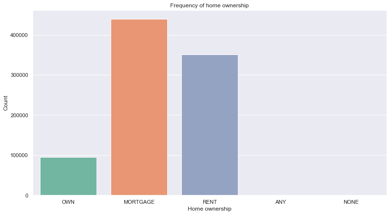

```python
sns.set(rc = {'figure.figsize':(13,7)})
sns.countplot(loans['home_ownership'], palette = 'Set2')
plt.xlabel("Home ownership")
plt.ylabel("Count")
plt.title("Frequency of home ownership")
plt.show
```

The vast majority of people who apply for a loan have a mortgage or rent, a small percentage own a home.

#### Term

```
<function matplotlib.pyplot.show(*args, **kw)>
```

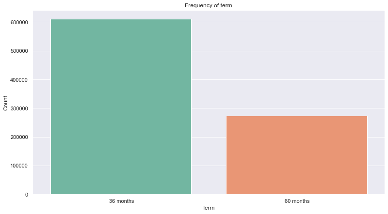

```python
sns.set(rc = {'figure.figsize':(13,7)})
sns.countplot(loans['term'], palette = 'Set2')
plt.xlabel("Term")
plt.ylabel("Count")
plt.title("Frequency of term")
plt.show
```

#### Credit Grade

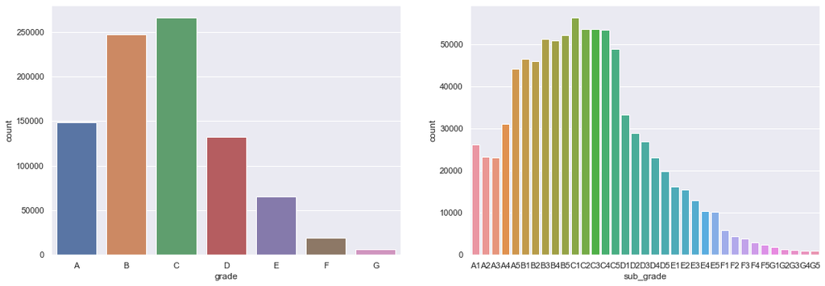

```python
fig, axs = plt.subplots(1,2, figsize = (18,6))
sns.countplot(loans['grade'], order = ('A','B','C','D','E','F','G'), ax = axs[0])

l = []
for i in ['A', 'B', 'C', 'D', 'E', 'F', 'G']:
    for j in ['1', '2', '3', '4', '5']:
        l.append(i+j)

sns.countplot(loans['sub_grade'], order = l, ax = axs[1])

plt.show()
```

Most loans are classified with the letter B and C.

### Bivariate/Multivariate Analysis

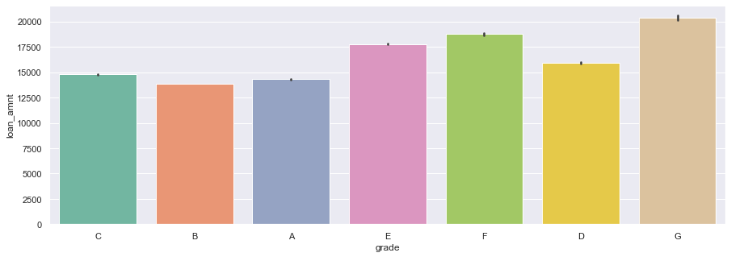

```python
plt.figure(figsize = (15,5))
sns.barplot(x ='grade', y='loan_amnt', data=loans, palette = 'Set2')
```

There is a direct relation between loan amount and grade, to lower grade more loan amount.

#### Loan amount vs loan status

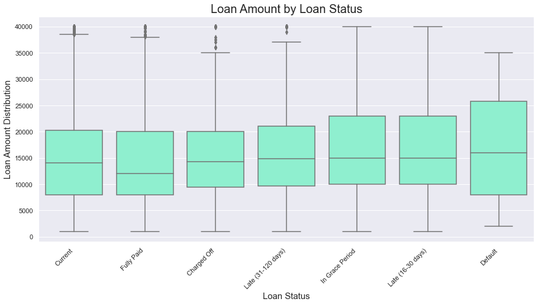

```python
plt.figure(figsize = (15,7))

g2 = sns.boxplot(x = "loan_status", y="loan_amnt", data=loans, order = loans['loan_status'].value_counts().index,color='aquamarine')
g2.set_xticklabels(g2.get_xticklabels(), fontdict = {'horizontalalignment':'right'}, rotation = 45)
g2.set_xlabel("Loan Status", fontsize = 15)
g2.set_ylabel("Loan Amount Distribution", fontsize = 15)
g2.set_title("Loan Amount by Loan Status", fontsize = 20)

plt.show()
```

#### Loan Amount Versus Purpose

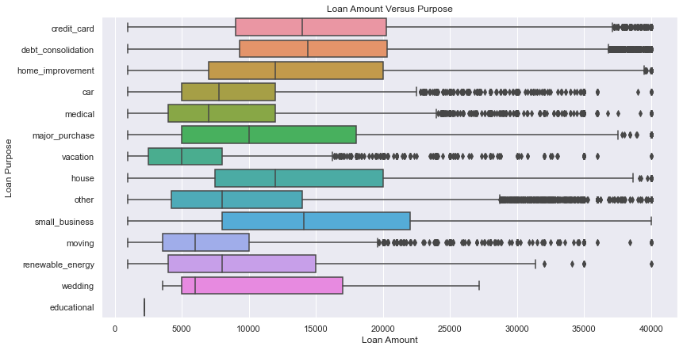

```python
plt.figure(figsize=(13,7))
ax = sns.boxplot(y = "purpose", x = "loan_amnt", data=loans)
ax = plt.xlabel('Loan Amount')
ax = plt.ylabel('Loan Purpose')
ax = plt.title('Loan Amount Versus Purpose')
```

The top purposes with the highest loan amount are credit card, small business, debt consolidation, home improvement and house.

#### Annual Income Versus Employment Length

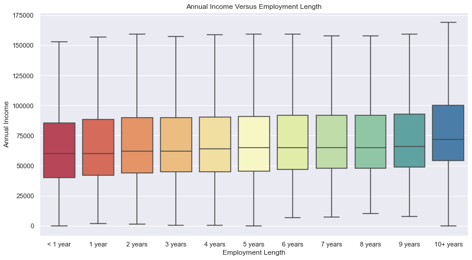

```python
plt.figure(figsize = (13,7))

cols = ['< 1 year','1 year','2 years','3 years','4 years','5 years','6 years','7 years','8 years','9 years','10+ years']

ax = sns.boxplot(x = "emp_length", y = "annual_inc",  data = loans, order = cols, showfliers = False, palette = 'Spectral')

ax = plt.ylabel('Annual Income')
ax = plt.xlabel('Employment Length')
ax = plt.title('Annual Income Versus Employment Length')
```

Those who works longer get paid more annually.

#### Loan amount applied by borrower, funded amount by lender and funded amount by investors

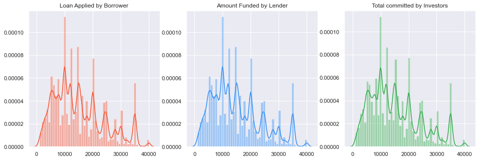

```python
ig, ax = plt.subplots(1, 3, figsize = (16,5))

loan_amount = loans["loan_amnt"].values
funded_amount = loans["funded_amnt"].values
investor_funds = loans["funded_amnt_inv"].values

sns.distplot(loan_amount, ax=ax[0], color = "#F7522F")
ax[0].set_title("Loan Applied by Borrower", fontsize = 12)
sns.distplot(funded_amount, ax=ax[1], color = "#2F8FF7")
ax[1].set_title("Amount Funded by Lender", fontsize = 12)
sns.distplot(investor_funds, ax=ax[2], color = "#2EAD46")
ax[2].set_title("Total committed by Investors", fontsize = 12)
```

## Final dataset

After selecting the most relevant variables our dataset is as follows:

```python
loans_final = loans[['term', 'loan_amnt','installment','int_rate', 'home_ownership','purpose',
                    'verification_status', 'annual_inc', 'emp_length', 'revol_util',
                    'revol_bal','pub_rec','open_acc', 'inq_last_6mths','delinq_2yrs','dti',
                    'total_acc', 'tax_liens','pub_rec_bankruptcies',
                    'loan_status','funded_amnt_inv','funded_amnt','total_pymnt','grade','sub_grade']]
sub_loans = loans_final.head(500)
sub_loans
```

|  | term | loan_amnt | installment | int_rate | home_ownership | purpose | verification_status | annual_inc | emp_length | revol_util | ... | dti | total_acc | tax_liens | pub_rec_bankruptcies | loan_status | funded_amnt_inv | funded_amnt | total_pymnt | grade | sub_grade |
| --- | --- | --- | --- | --- | --- | --- | --- | --- | --- | --- | --- | --- | --- | --- | --- | --- | --- | --- | --- | --- | --- |
| 0 | 36 months | 2300 | 77.08 | 12.62% | OWN | credit_card | Not Verified | 10000.0 | NaN | 55.1% | ... | 21.61 | 6 | 0 | 0 | Current | 2300.0 | 2300 | 382.99 | C | C1 |
| 1 | 60 months | 16000 | 360.95 | 12.62% | MORTGAGE | debt_consolidation | Not Verified | 94000.0 | 10+ years | 105.8% | ... | 25.61 | 26 | 0 | 0 | Current | 16000.0 | 16000 | 2060.09 | C | C1 |
| 2 | 36 months | 6025 | 209.01 | 15.05% | MORTGAGE | home_improvement | Not Verified | 46350.0 | 7 years | 44.9% | ... | 8.88 | 27 | 0 | 0 | Current | 6025.0 | 6025 | 1032.46 | C | C4 |
| 3 | 36 months | 20400 | 652.91 | 9.44% | RENT | car | Source Verified | 44000.0 | 10+ years | 18.7% | ... | 27.06 | 19 | 0 | 0 | Current | 20400.0 | 20400 | 3237.80 | B | B1 |
| 4 | 36 months | 13000 | 431.73 | 11.99% | MORTGAGE | debt_consolidation | Source Verified | 85000.0 | 10+ years | 88% | ... | 6.79 | 24 | 0 | 0 | Current | 13000.0 | 13000 | 2137.00 | B | B5 |
| ... | ... | ... | ... | ... | ... | ... | ... | ... | ... | ... | ... | ... | ... | ... | ... | ... | ... | ... | ... | ... | ... |
| 495 | 36 months | 14950 | 600.92 | 25.82% | RENT | debt_consolidation | Source Verified | 34000.0 | 2 years | 59.8% | ... | 34.31 | 20 | 0 | 0 | Current | 14950.0 | 14950 | 2950.99 | E | E4 |
| 496 | 36 months | 15000 | 498.15 | 11.99% | RENT | debt_consolidation | Verified | 60000.0 | 5 years | 71.5% | ... | 6.62 | 23 | 0 | 0 | Current | 15000.0 | 15000 | 2465.77 | B | B5 |
| 497 | 60 months | 12000 | 257.46 | 10.42% | MORTGAGE | debt_consolidation | Not Verified | 62000.0 | 10+ years | 20.7% | ... | 25.92 | 46 | 0 | 0 | Current | 12000.0 | 12000 | 1269.93 | B | B3 |
| 498 | 36 months | 4000 | 128.02 | 9.44% | MORTGAGE | home_improvement | Not Verified | 50000.0 | 10+ years | 3.8% | ... | 18.24 | 36 | 0 | 1 | Current | 4000.0 | 4000 | 634.86 | B | B1 |
| 499 | 36 months | 32000 | 991.15 | 7.21% | MORTGAGE | debt_consolidation | Not Verified | 85000.0 | 7 years | 31.2% | ... | 18.99 | 32 | 0 | 0 | Current | 32000.0 | 32000 | 4923.71 | A | A3 |

500 rows × 25 columns

The dataset sub_loans is a DataFrame

```python
type(sub_loans)
```

```
pandas.core.frame.DataFrame
```

We see the type of our final variables.

```python
sub_loans.dtypes
```

```
term                     object
loan_amnt                 int64
installment             float64
int_rate                 object
home_ownership           object
purpose                  object
verification_status      object
annual_inc              float64
emp_length               object
revol_util               object
revol_bal                 int64
pub_rec                   int64
open_acc                  int64
inq_last_6mths            int64
delinq_2yrs               int64
dti                     float64
total_acc                 int64
tax_liens                 int64
pub_rec_bankruptcies      int64
loan_status              object
funded_amnt_inv         float64
funded_amnt               int64
total_pymnt             float64
grade                    object
sub_grade                object
dtype: object
```

And we check the percentage of null values of the final dataset.

```python
percentage_NaN = sub_loans.apply(lambda x: sum(x.isna()/len(sub_loans)))
percentage_NaN.sort_values(ascending = False)
```

```
emp_length              0.06
sub_grade               0.00
pub_rec                 0.00
loan_amnt               0.00
installment             0.00
int_rate                0.00
home_ownership          0.00
purpose                 0.00
verification_status     0.00
annual_inc              0.00
revol_util              0.00
revol_bal               0.00
open_acc                0.00
grade                   0.00
inq_last_6mths          0.00
delinq_2yrs             0.00
dti                     0.00
total_acc               0.00
tax_liens               0.00
pub_rec_bankruptcies    0.00
loan_status             0.00
funded_amnt_inv         0.00
funded_amnt             0.00
total_pymnt             0.00
term                    0.00
dtype: float64
```

Finally, to have a general image of the chosen variables and of our final dataset, we are going to visualize how they are related with a correlation heatmap, a pair plot and we are going to see the frequencies with a histogram.

### Correlation

```python
corr1 = sub_loans.corr()
corr1
```

|  | loan_amnt | installment | annual_inc | revol_bal | pub_rec | open_acc | inq_last_6mths | delinq_2yrs | dti | total_acc | tax_liens | pub_rec_bankruptcies | funded_amnt_inv | funded_amnt | total_pymnt |
| --- | --- | --- | --- | --- | --- | --- | --- | --- | --- | --- | --- | --- | --- | --- | --- |
| loan_amnt | 1.000000 | 0.949675 | 0.495071 | 0.337899 | -0.089667 | 0.144392 | -0.025257 | -0.037241 | 0.015951 | 0.193126 | 0.016096 | -0.146038 | 1.000000 | 1.000000 | 0.455451 |
| installment | 0.949675 | 1.000000 | 0.470869 | 0.271532 | -0.064948 | 0.146724 | 0.000014 | -0.031638 | -0.001243 | 0.192955 | 0.039074 | -0.128936 | 0.949675 | 0.949675 | 0.504856 |
| annual_inc | 0.495071 | 0.470869 | 1.000000 | 0.445962 | -0.075491 | 0.183897 | 0.137075 | 0.053128 | -0.144041 | 0.296633 | -0.006878 | -0.085581 | 0.495071 | 0.495071 | 0.269276 |
| revol_bal | 0.337899 | 0.271532 | 0.445962 | 1.000000 | -0.120088 | 0.190854 | 0.101234 | -0.054418 | 0.041992 | 0.235235 | -0.053508 | -0.105279 | 0.337899 | 0.337899 | 0.091077 |
| pub_rec | -0.089667 | -0.064948 | -0.075491 | -0.120088 | 1.000000 | 0.021222 | 0.032891 | -0.090608 | -0.021586 | -0.022993 | 0.586497 | 0.669437 | -0.089667 | -0.089667 | -0.045474 |
| open_acc | 0.144392 | 0.146724 | 0.183897 | 0.190854 | 0.021222 | 1.000000 | 0.149990 | 0.032097 | 0.118785 | 0.762485 | -0.026142 | -0.005255 | 0.144392 | 0.144392 | 0.132012 |
| inq_last_6mths | -0.025257 | 0.000014 | 0.137075 | 0.101234 | 0.032891 | 0.149990 | 1.000000 | 0.008522 | -0.046548 | 0.176477 | 0.001053 | 0.046591 | -0.025257 | -0.025257 | -0.001859 |
| delinq_2yrs | -0.037241 | -0.031638 | 0.053128 | -0.054418 | -0.090608 | 0.032097 | 0.008522 | 1.000000 | -0.005757 | 0.062022 | -0.027797 | -0.078937 | -0.037241 | -0.037241 | -0.019942 |
| dti | 0.015951 | -0.001243 | -0.144041 | 0.041992 | -0.021586 | 0.118785 | -0.046548 | -0.005757 | 1.000000 | 0.212085 | -0.008748 | -0.015425 | 0.015951 | 0.015951 | -0.017967 |
| total_acc | 0.193126 | 0.192955 | 0.296633 | 0.235235 | -0.022993 | 0.762485 | 0.176477 | 0.062022 | 0.212085 | 1.000000 | -0.070678 | 0.004130 | 0.193126 | 0.193126 | 0.176916 |
| tax_liens | 0.016096 | 0.039074 | -0.006878 | -0.053508 | 0.586497 | -0.026142 | 0.001053 | -0.027797 | -0.008748 | -0.070678 | 1.000000 | -0.004634 | 0.016096 | 0.016096 | -0.018356 |
| pub_rec_bankruptcies | -0.146038 | -0.128936 | -0.085581 | -0.105279 | 0.669437 | -0.005255 | 0.046591 | -0.078937 | -0.015425 | 0.004130 | -0.004634 | 1.000000 | -0.146038 | -0.146038 | -0.043669 |
| funded_amnt_inv | 1.000000 | 0.949675 | 0.495071 | 0.337899 | -0.089667 | 0.144392 | -0.025257 | -0.037241 | 0.015951 | 0.193126 | 0.016096 | -0.146038 | 1.000000 | 1.000000 | 0.455451 |
| funded_amnt | 1.000000 | 0.949675 | 0.495071 | 0.337899 | -0.089667 | 0.144392 | -0.025257 | -0.037241 | 0.015951 | 0.193126 | 0.016096 | -0.146038 | 1.000000 | 1.000000 | 0.455451 |
| total_pymnt | 0.455451 | 0.504856 | 0.269276 | 0.091077 | -0.045474 | 0.132012 | -0.001859 | -0.019942 | -0.017967 | 0.176916 | -0.018356 | -0.043669 | 0.455451 | 0.455451 | 1.000000 |

Best way to see a overall picture of the relationships between features is to use a heatmap.

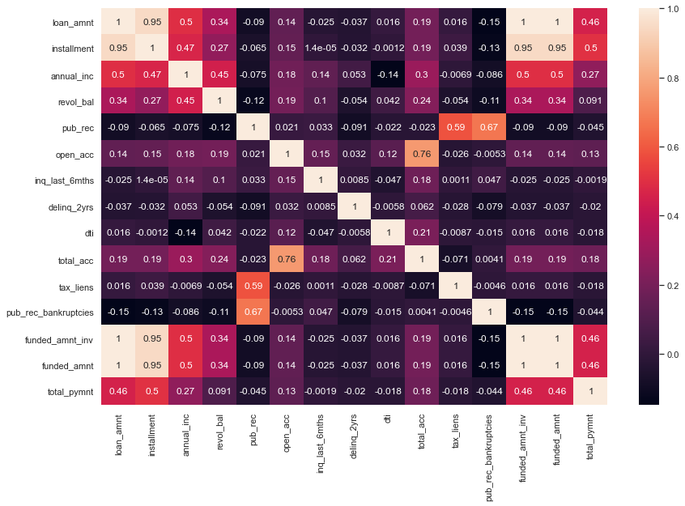

```python
f, ax = plt.subplots(figsize=(14, 9))
sns.heatmap(corr1,
            xticklabels=corr1.columns.values,
            yticklabels=corr1.columns.values,annot= True)
plt.show()
```

### Pair Plot

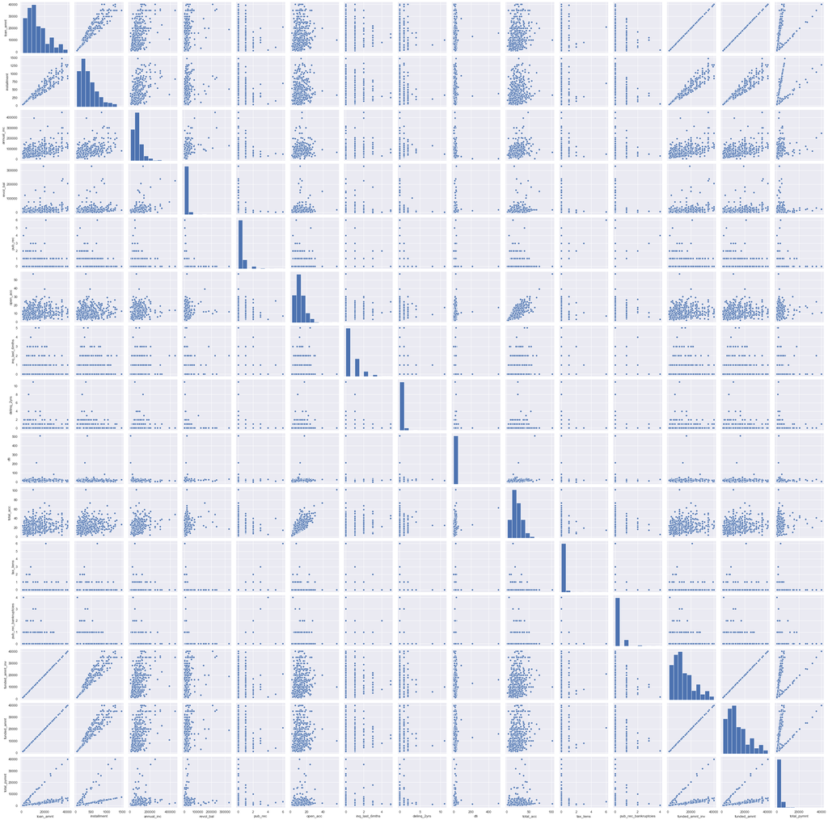

```python
sns.pairplot(sub_loans[['term', 'loan_amnt','installment','int_rate', 'home_ownership','purpose',
                    'verification_status', 'annual_inc', 'emp_length', 'revol_util',
                    'revol_bal','pub_rec','open_acc', 'inq_last_6mths','delinq_2yrs','dti',
                    'total_acc', 'tax_liens','pub_rec_bankruptcies',
                    'loan_status','funded_amnt_inv','funded_amnt','total_pymnt','grade','sub_grade']]);
```

### Histograms

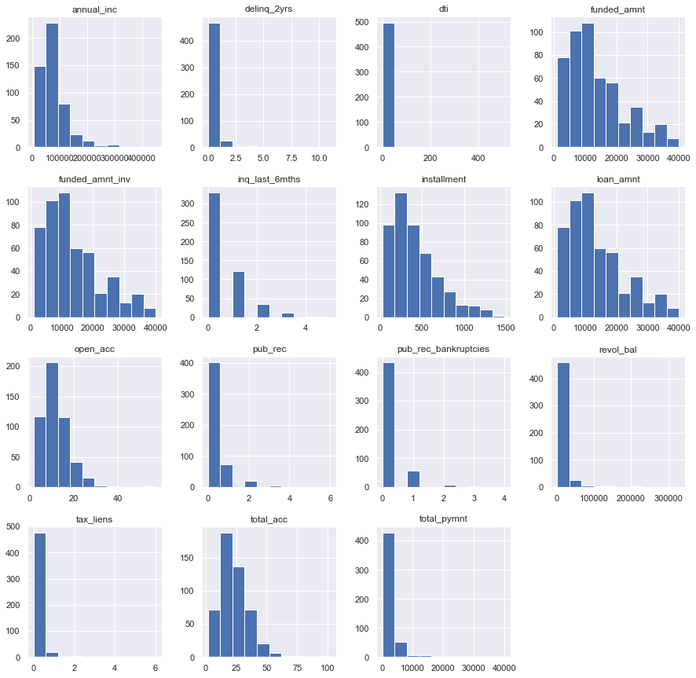

```python
sub_loans.hist(figsize = (15, 15))
plt.show()
```

```python
loans.to_csv('./data/EDA_loans_final.csv', index = None, header=True)
```